# Homework 2

**Due October 2 prior to 1:30 PM. Assignments are to be submitted via Canvas.**

**You may discuss the homework problems and computing issues with other students in the class and submit questions to the Canvas discussion board. However, you must write up your homework solution on your own. In particular, do not share your R files with other students. Please list the students you worked with below:**

### Lectures: Module 2

### Objectives:

1. Learn more about ICC.
2. Fit and interpret a mixed model with random intercepts.
3. Fit and interpret a mixed model with random slopes.
4. Understand the importance of incorporating correlation between observations into your models.

# Problem 1.

Dataset: thalamus_mb_selected.csv

We will continue to examine whether measures of brain activity differ between acquisition sequences. The acquisitions all purport to measure the same thing, i.e., neural activity, and in this sense should not differ.

Last time we used `%in%` to subset to SB3.3.mm and MB.4. This time we will use `dplyr::filter`:

```r
mbdata = read.csv("thalamus_mb_selected.csv")
library('dplyr')
mbdata_sel = mbdata %>% filter(Acquisition%in%c('SB.3.3.mm','MB.4'))
```

**1.** ICC is used in reproducibility studies. Calculate ICC of `zcor` using the original definition. The original definition is defined similar to Pearson’s correlation but uses a shared mean:
$$\frac{1}{n}\sum_{i=1}^n((y_{i1} -
\bar{y}_{\cdot \cdot})(y_{i2}-\bar{y}_{\cdot
\cdot})/var(y_{ij}),$$
where $y_{\cdot \cdot} = \frac{1}{2n} \sum_{i=1}^n \sum_{j=1}^2 y_{ij}$ and $var(y_{ij})=\sum_{i=1}^n \sum_{j=1}^2 (y_{ij} - \bar{y}_{\cdot \cdot})^2/(2n)$. Here, $j=1$ corresponds to SB.3.3.mm and $j=2$ corresponds to MB.4. In order to do this, if a subject is missing `zcor` for SB.3.3.mm or MB.4, remove that subject from the calculation

```r
library(tidyr)
# reshape data into wide format
mbdata_sel_wide = mbdata_sel %>%
  select(id, Acquisition, zcor) %>%
  pivot_wider(names_from = Acquisition, values_from = zcor)
# remove subject with missing 'zcor' for SB.3.3.mm or MB.4
mbdata_sel_wide_complete = mbdata_sel_wide[complete.cases(mbdata_sel_wide),]
zcor.SB = unlist(mbdata_sel_wide_complete[,'SB.3.3.mm'])
zcor.MB = unlist(mbdata_sel_wide_complete[,'MB.4'])

# calculate the shared mean \bar{y}
y_bar = mean(c(zcor.SB, zcor.MB))
# calculate var(y_{ij})
var_yij = mean(c((zcor.SB - y_bar)^2, (zcor.MB - y_bar)^2))
# calculate icc
icc = (mean((zcor.SB - y_bar) * (zcor.MB - y_bar)))/ (var_yij)
print(icc)
```

```
## [1] -0.1218052
```

**2.** Next, fit a random intercept model to the data including all subjects. Do not include any covariates, and use the default REML fitting. Print the output of `summary()`.

```r
library(lmerTest)
model0 = lmer(zcor~(1|id),data=mbdata_sel)
```

```
## boundary (singular) fit: see help('isSingular')
```

```r
summary(model0)
```

```
## Linear mixed model fit by REML. t-tests use Satterthwaite's method [
## lmerModLmerTest]
## Formula: zcor ~ (1 | id)
##    Data: mbdata_sel
##
## REML criterion at convergence: 37
##
## Scaled residuals:
##     Min      1Q  Median      3Q     Max
## -1.6693 -0.6971 -0.0531  0.6714  2.5434
##
## Random effects:
##  Groups   Name        Variance Std.Dev.
##  id       (Intercept) 0.0000   0.0000
##  Residual             0.1003   0.3167
## Number of obs: 62, groups:  id, 32
##
## Fixed effects:
##             Estimate Std. Error       df t value Pr(>|t|)
## (Intercept)  0.73074    0.04022 61.00000   18.17   <2e-16 ***
## ---
## Signif. codes:  0 '***' 0.001 '**' 0.01 '*' 0.05 '.' 0.1 ' ' 1
## optimizer (nloptwrap) convergence code: 0 (OK)
## boundary (singular) fit: see help('isSingular')
```

**3.** Calculate the mixed model formulation of ICC. This more modern approach allows the use of participants that may be missing a first or second scan. Then based on the guidelines for reproducibility below, how is the reproducibility of brain activity between the two acquisitions?

Less than 0.40—poor.

Between 0.40 and 0.59—fair.

Between 0.60 and 0.74—good.

Between 0.75 and 1.00—excellent.

```r
# extract tau^2 and sigma^2
tau2 <- VarCorr(model0)$id[1]
sigma2 <- summary(model0)$sigma^2

# compute icc
icc <- tau2 / (tau2 + sigma2)
print(icc)
```

```
## [1] 0
```

The mixed model formulation of ICC is 0, indicating poor reproducibility of brain activity between the two acquisitions.

**4.** Next, fit a linear mixed model with outcome `zcor` and a fixed effect `Acquisition` and a random intercept for `id` on the SB.3.3.mm and MB.4 data. Print `summary()` and include the p-values.

```r
model1=lmer(zcor~Acquisition+(1|id),data=mbdata_sel)
summary(model1)
```

```
## Linear mixed model fit by REML. t-tests use Satterthwaite's method [
## lmerModLmerTest]
## Formula: zcor ~ Acquisition + (1 | id)
##    Data: mbdata_sel
##
## REML criterion at convergence: 22.2
##
## Scaled residuals:
##     Min      1Q  Median      3Q     Max
## -1.6578 -0.6655 -0.1860  0.7358  2.1935
##
## Random effects:
##  Groups   Name        Variance Std.Dev.
##  id       (Intercept) 0.01504  0.1227
##  Residual             0.06194  0.2489
## Number of obs: 62, groups:  id, 32
##
## Fixed effects:
##                      Estimate Std. Error       df t value Pr(>|t|)
## (Intercept)           0.57301    0.04980 58.11306  11.505  < 2e-16 ***
## AcquisitionSB.3.3.mm  0.31432    0.06341 30.24147   4.957 2.58e-05 ***
## ---
## Signif. codes:  0 '***' 0.001 '**' 0.01 '*' 0.05 '.' 0.1 ' ' 1
##
## Correlation of Fixed Effects:
##             (Intr)
## AcqsSB.3.3. -0.637
```

**5.** Write the model for problem 4. R markdown can use “latex” (pronounced lay-tek) notation to create Greek letters. If you are compiling your homework in html, you may be able to compile this without installing additional software. If you encounter issues, you can try typing `tinytex::install_tinytex()` in the R Console. There are examples above in problem 1. Here is another example:
$$y_i = \beta_0 + \beta_1 x_i + \epsilon_i$$
$$\epsilon_i \overset{iid}{\sim}
N(0,\sigma^2).$$
Make sure to use two indices when appropriate, e.g., $y_{ij}$. Use $\tau^2$ for the random intercept variance. (Note: use a single dollar sign for in-line equations, and two dollars signs for an equation on a new line, see this R markdown file.) Define all notation.

$$y_{ij} = \mu + \theta_i + \beta \times \text{Acquisition}_{ij} +
\epsilon_{ij}$$

We assume:

$$\theta_i \stackrel{iid}{\sim} N(0, \tau^2)\\
\epsilon_{ij} \stackrel{iid}{\sim} N(0, \sigma^2) \\
\theta_i \perp \!\!\! \perp \epsilon_{ij}$$

**6.** Re-calculate the paired t-test from HW1 and compare the t-statistic and p-value to the mixed model. Are they the same?

```r
t.test(mbdata_sel_wide$SB.3.3.mm,mbdata_sel_wide$MB.4,paired = TRUE)
```

```
##
##  Paired t-test
##
## data:  mbdata_sel_wide$SB.3.3.mm and mbdata_sel_wide$MB.4
## t = 5.1113, df = 29, p-value = 1.862e-05
## alternative hypothesis: true difference in means is not equal to 0
## 95 percent confidence interval:
##  0.1969103 0.4596117
## sample estimates:
## mean of the differences
##                0.328261
```

No, the t-statistics and p-value are not same.

**7.** If any of the subjects are missing `zcor` for SB.3.3.mm or MB.4, remove that subject from the dataset. Refit the lmm. How does the t-statistic and p-value compare to the paired t-test? (Note that an advantage of the more modern mixed models is that they can handle subjects that have partially missing data.)

```r
model1.7 = lmer(zcor~Acquisition+(1|id), data = mbdata_sel %>% filter(id %in% mbdata_sel_wide_complete$id))
summary(model1.7)
```

```
## Linear mixed model fit by REML. t-tests use Satterthwaite's method [
## lmerModLmerTest]
## Formula: zcor ~ Acquisition + (1 | id)
##    Data: mbdata_sel %>% filter(id %in% mbdata_sel_wide_complete$id)
##
## REML criterion at convergence: 21.5
##
## Scaled residuals:
##     Min      1Q  Median      3Q     Max
## -1.6952 -0.6258 -0.1953  0.7149  2.1557
##
## Random effects:
##  Groups   Name        Variance Std.Dev.
##  id       (Intercept) 0.01510  0.1229
##  Residual             0.06187  0.2487
## Number of obs: 60, groups:  id, 30
##
## Fixed effects:
##                      Estimate Std. Error       df t value Pr(>|t|)
## (Intercept)           0.56963    0.05065 55.85081  11.246 5.68e-16 ***
## AcquisitionSB.3.3.mm  0.32826    0.06422 29.00000   5.111 1.86e-05 ***
## ---
## Signif. codes:  0 '***' 0.001 '**' 0.01 '*' 0.05 '.' 0.1 ' ' 1
##
## Correlation of Fixed Effects:
##             (Intr)
## AcqsSB.3.3. -0.634
```

The t-statistics and p-value are identical to those obtained from the paired t-test.

**8.** Now we will fit an lmm to all acquisitions in `mbdata`. Use `SB.2.mm` as the reference for `Acquisition`. The response variable is `zcor`, and include `gender`, `scanner`, and `Acquisition` as fixed effects, and `id` as a random intercept. Print the output of `summary()`.

```r
mbdata$Acquisition = relevel(factor(mbdata$Acquisition), ref = 'SB.2.mm')
model1.8 = lmer(zcor~Acquisition+gender+scanner+(1|id),
              data = mbdata)
summary(model1.8)
```

```
## Linear mixed model fit by REML. t-tests use Satterthwaite's method [
## lmerModLmerTest]
## Formula: zcor ~ Acquisition + gender + scanner + (1 | id)
##    Data: mbdata
##
## REML criterion at convergence: -23.2
##
## Scaled residuals:
##     Min      1Q  Median      3Q     Max
## -2.4601 -0.6332 -0.0724  0.5658  3.5088
##
## Random effects:
##  Groups   Name        Variance Std.Dev.
##  id       (Intercept) 0.01071  0.1035
##  Residual             0.04069  0.2017
## Number of obs: 277, groups:  id, 32
##
## Fixed effects:
##                        Estimate Std. Error         df t value Pr(>|t|)
## (Intercept)            0.541508   0.053201  82.369049  10.179 3.16e-16 ***
## AcquisitionMB.12      -0.359084   0.050871 237.529345  -7.059 1.84e-11 ***
## AcquisitionMB.2        0.069437   0.051784 238.331414   1.341    0.181
## AcquisitionMB.3       -0.045796   0.052285 238.723676  -0.876    0.382
## AcquisitionMB.4        0.022137   0.051315 237.992504   0.431    0.667
## AcquisitionMB.6       -0.082737   0.050871 237.529345  -1.626    0.105
## AcquisitionMB.8       -0.309769   0.050871 237.529345  -6.089 4.52e-09 ***
## AcquisitionMB.9       -0.298630   0.052272 238.549180  -5.713 3.29e-08 ***
## AcquisitionSB.3.3.mm   0.337458   0.051315 237.992471   6.576 3.03e-10 ***
## genderM                0.028298   0.044288  29.135197   0.639    0.528
## scannerCSIC           -0.007675   0.045914  29.541255  -0.167    0.868
## ---
## Signif. codes:  0 '***' 0.001 '**' 0.01 '*' 0.05 '.' 0.1 ' ' 1
##
## Correlation of Fixed Effects:
##             (Intr) AMB.12 AcMB.2 AcMB.3 AcMB.4 AcMB.6 AcMB.8 AcMB.9 ASB.3.
## AcqstnMB.12 -0.491
## AcqustnMB.2 -0.475  0.500
## AcqustnMB.3 -0.465  0.495  0.490
## AcqustnMB.4 -0.481  0.504  0.495  0.492
## AcqustnMB.6 -0.491  0.509  0.500  0.495  0.504
## AcqustnMB.8 -0.491  0.509  0.500  0.495  0.504  0.509
## AcqustnMB.9 -0.473  0.495  0.486  0.483  0.492  0.495  0.495
## AcqsSB.3.3. -0.481  0.504  0.497  0.492  0.500  0.504  0.504  0.491
## genderM     -0.353  0.004  0.005  0.000 -0.001  0.004  0.004 -0.011 -0.001
## scannerCSIC -0.493  0.005 -0.008 -0.015 -0.001  0.005  0.005  0.007 -0.001
##             gendrM
## AcqstnMB.12
## AcqustnMB.2
## AcqustnMB.3
## AcqustnMB.4
## AcqustnMB.6
## AcqustnMB.8
## AcqustnMB.9
## AcqsSB.3.3.
## genderM
## scannerCSIC -0.124
```

**9.** Read the section *Diagnostics* in [Bates et al, “Fitting Linear Mixed-Effects Models Using lme4,” Journal of Statistical Software, 2015](https://www.jstatsoft.org/article/view/v067i01). Perform model diagnostics by creating the three plots described there (fitted versus residual, scale-location, and quantile-quantile plots). Note you will need the library `lattice` to use `qqmath()`. Are there any potential issues?

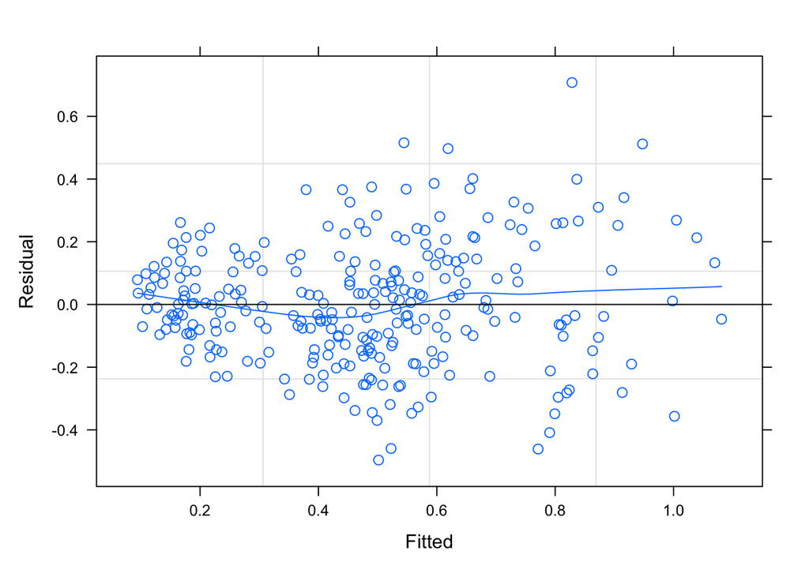

```r
plot(model1.8, type = c("p", "smooth"),
     xlab = "Fitted", ylab = "Residual")
```

The fitted versus residual plot is used to check the linearity assumption and homoscedasticity. The blue line is not flat, which indicates a violation of the linearity assumption. The residuals are more spread out for large fitted values, indicating a violation of homoscedasticity.

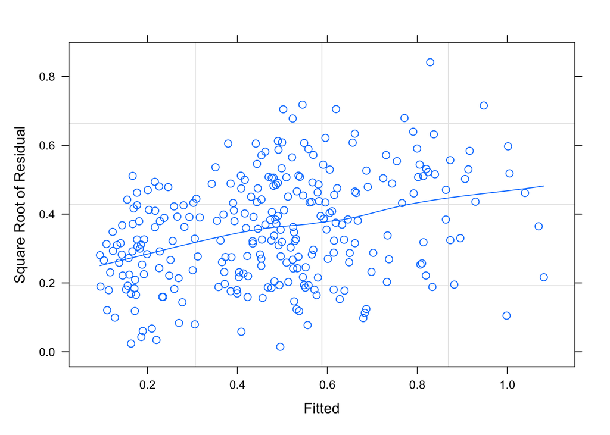

```r
plot(model1.8, sqrt(abs(resid(.))) ~ fitted(.), type = c("p", "smooth"),
     xlab = "Fitted", ylab = "Square Root of Residual")
```

The scale-location plot is used to check the homoscedasticity. The blue line is not flat, which indicates a violation of homoscedasticity.

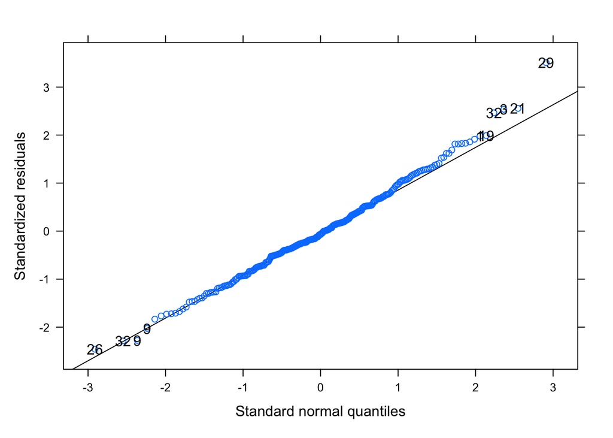

```r
library(lattice)
qqmath(model1.8, id = 0.05)
```

The quantile-quantile plot is used to assess the normality assumption. While there are some departures in the tails, the normality assumption is not a major concern in this case.

**10.** In multiple regression, we examined the influence of single data points by examining how the model changed when that data point was removed. In mixed models, we can examine the influence of removing one subject. We will do this using a package called `influence.ME`. Plot the Cook’s distances that are calculated by refitting the model after removing one subject. This can be done adapting the following code chunk: `plot(influence(mymixedmodel,group='id'),which='cook')`. Are there any large issues?

```r
library(influence.ME)
```

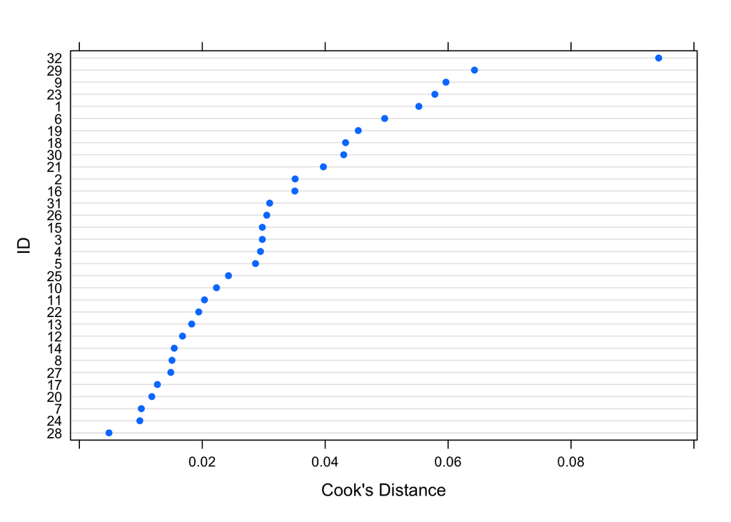

```r
plot(influence(model1.8, group = "id"), which="cook", sort=TRUE,
xlab="Cook's Distance",
ylab="ID")
```

The Cook distance’s are scaled differently than in multiple regression. In [Nieuwenhuis et al](https://journal.r-project.org/archive/2012-2/RJournal_2012-2_Nieuwenhuis~et~al.pdf), the authors use a cutoff of 4/(number of subjects). No subjects have Cook’s distance exceed the threshold 4/32 = 0.125.

**11.** Now test the hypothesis that acquisition has a significant effect on the z-transformed correlations when controlling for gender and scanner type. Summarize your findings using complete sentences, stating the result, test statistic, degrees of freedom, and p-value.

```r
model1.8_ml <- lmer(zcor~Acquisition+gender+scanner+(1|id), data = mbdata,REML=FALSE)
model1.8_reduced_ml <- lmer(zcor~gender+scanner+(1|id), data = mbdata,REML=FALSE)
anova(model1.8_reduced_ml, model1.8_ml)
```

```
## Data: mbdata
## Models:
## model1.8_reduced_ml: zcor ~ gender + scanner + (1 | id)
## model1.8_ml: zcor ~ Acquisition + gender + scanner + (1 | id)
##                     npar     AIC     BIC logLik deviance  Chisq Df Pr(>Chisq)
## model1.8_reduced_ml    5 135.300 153.420 -62.65  125.300
## model1.8_ml           13 -48.161  -1.049  37.08  -74.161 199.46  8  < 2.2e-16
##
## model1.8_reduced_ml
## model1.8_ml         ***
## ---
## Signif. codes:  0 '***' 0.001 '**' 0.01 '*' 0.05 '.' 0.1 ' ' 1
```

The likelihood ratio test yields a chi-squared statistic of 199.46 with 8 degrees of freedom. The corresponding p-value is less than $2.2 \times 10^{-16}$, which is below the significance level of 0.05. We reject the null hypothesis and conclude that the acquisition has a significant effect on the z-transformed correlations when controlling for gender and scanner type.

# Problem 2.

For this problem, we again use the Parkinson’s dataset, `parkinsons.csv`.

**1.** Fit a linear mixed model with `motor_UPDRS` as the response variable, `subject` as a random intercept, and `age`, `sex`, `Jitter_Percent`, `Shimmer`, `NHR`, and `PPE` as fixed effects. Do not re-scale any variables. Print the output of `summary()`. Are there any warnings? (Note: we should also check model assumptions as in Problem 1, but in the interest of time, we will skip these important checks.)

```r
pdata = read.csv('parkinsons.csv')
# factorize the variable "subject"
pdata$subject = as.factor(pdata$subject)
model2.1 = lmer(motor_UPDRS~age+sex+Jitter_Percent+Shimmer+NHR+PPE+(1|subject),data=pdata)
```

```
## Warning: Some predictor variables are on very different scales: consider
## rescaling

## Warning: Some predictor variables are on very different scales: consider
## rescaling
```

```r
summary(model2.1)
```

```
## Linear mixed model fit by REML. t-tests use Satterthwaite's method [
## lmerModLmerTest]
## Formula: motor_UPDRS ~ age + sex + Jitter_Percent + Shimmer + NHR + PPE +
##     (1 | subject)
##    Data: pdata
##
## REML criterion at convergence: 26936.7
##
## Scaled residuals:
##     Min      1Q  Median      3Q     Max
## -3.8073 -0.5689  0.0291  0.5244  4.4620
##
## Random effects:
##  Groups   Name        Variance Std.Dev.
##  subject  (Intercept) 59.726   7.728
##  Residual              5.467   2.338
## Number of obs: 5875, groups:  subject, 42
##
## Fixed effects:
##                 Estimate Std. Error        df t value Pr(>|t|)
## (Intercept)       4.9250     8.6135   39.0076   0.572   0.5708
## age               0.2552     0.1310   39.0046   1.949   0.0585 .
## sex              -0.5764     2.5360   39.0096  -0.227   0.8214
## Jitter_Percent   33.3655    13.1847 5833.6871   2.531   0.0114 *
## Shimmer          -4.9715     2.4481 5833.0358  -2.031   0.0423 *
## NHR              -2.9881     1.4707 5837.1009  -2.032   0.0422 *
## PPE              -0.7157     0.6419 5833.6225  -1.115   0.2649
## ---
## Signif. codes:  0 '***' 0.001 '**' 0.01 '*' 0.05 '.' 0.1 ' ' 1
##
## Correlation of Fixed Effects:
##             (Intr) age    sex    Jttr_P Shimmr NHR
## age         -0.985
## sex         -0.161  0.064
## Jittr_Prcnt -0.001  0.002  0.004
## Shimmer      0.000 -0.004  0.000 -0.117
## NHR          0.003  0.001 -0.010 -0.666 -0.299
## PPE         -0.008 -0.004  0.007 -0.377 -0.192  0.010
## fit warnings:
## Some predictor variables are on very different scales: consider rescaling
```

The two warnings are “Warning: Some predictor variables are on very different scales: consider rescaling.”

**2.** Now scale `age`. Use `scale()` such that the resulting variable has unit variance and mean zero. Re-fit the model from the previous question. Does the t-statistic of `age` change?

```r
model2.2 = lmer(motor_UPDRS~scale(age)+sex+Jitter_Percent+Shimmer+NHR+PPE+(1|subject),data=pdata)
summary(model2.2)
```

```
## Linear mixed model fit by REML. t-tests use Satterthwaite's method [
## lmerModLmerTest]
## Formula: motor_UPDRS ~ scale(age) + sex + Jitter_Percent + Shimmer + NHR +
##     PPE + (1 | subject)
##    Data: pdata
##
## REML criterion at convergence: 26932.4
##
## Scaled residuals:
##     Min      1Q  Median      3Q     Max
## -3.8073 -0.5689  0.0291  0.5244  4.4620
##
## Random effects:
##  Groups   Name        Variance Std.Dev.
##  subject  (Intercept) 59.726   7.728
##  Residual              5.467   2.338
## Number of obs: 5875, groups:  subject, 42
##
## Fixed effects:
##                 Estimate Std. Error        df t value Pr(>|t|)
## (Intercept)      21.4648     1.4661   39.5435  14.641   <2e-16 ***
## scale(age)        2.2515     1.1552   39.0046   1.949   0.0585 .
## sex              -0.5764     2.5360   39.0096  -0.227   0.8214
## Jitter_Percent   33.3655    13.1847 5833.6871   2.531   0.0114 *
## Shimmer          -4.9715     2.4481 5833.0358  -2.031   0.0423 *
## NHR              -2.9881     1.4707 5837.1009  -2.032   0.0422 *
## PPE              -0.7157     0.6419 5833.6225  -1.115   0.2649
## ---
## Signif. codes:  0 '***' 0.001 '**' 0.01 '*' 0.05 '.' 0.1 ' ' 1
##
## Correlation of Fixed Effects:
##             (Intr) scl(g) sex    Jttr_P Shimmr NHR
## scale(age)  -0.001
## sex         -0.575  0.064
## Jittr_Prcnt  0.007  0.002  0.004
## Shimmer     -0.022 -0.004  0.000 -0.117
## NHR          0.026  0.001 -0.010 -0.666 -0.299
## PPE         -0.068 -0.004  0.007 -0.377 -0.192  0.010
```

The t-statistic of `age` doesn’t change.

**3.** How do the p-values compare to the model without random effects that was fit in HW1 question 2.4 (the same model but without the random intercept)? Specifically, for each variable, list the p-value from the model without the random intercept versus the p-value from the mixed model.

```r
# The fixed model from HW1 Q2.4
hw1_model2.4 <- lm(motor_UPDRS~ age + sex + Jitter_Percent + Shimmer + NHR + PPE, data = pdata)

# get the p-values
p_in_fix = coef(summary(hw1_model2.4))[,'Pr(>|t|)']
p_in_mix = coef(summary(model2.2))[,'Pr(>|t|)']

# compare p-values
p_compare = cbind(p_in_fix, p_in_mix)
colnames(p_compare) = c('fixed effect model', 'mixed model')
pander::pander(p_compare)
```

|  | fixed effect model | mixed model |
| --- | --- | --- |
| **(Intercept)** | 9.635e-06 | 1.473e-17 |
| **age** | 2.426e-88 | 0.05851 |
| **sex** | 0.4789 | 0.8214 |
| **Jitter_Percent** | 0.008081 | 0.01141 |
| **Shimmer** | 0.5006 | 0.04232 |
| **NHR** | 0.04718 | 0.04222 |
| **PPE** | 1.427e-16 | 0.2649 |

The p-values of changed for all variables.

**4.** Next we will fit a model with random slopes. Some patients may have a more rapid rate of decline in `motor_UPDRS` than others. The variable `test_time` indicates the time since enrollment. First try to fit the model with the addition of a main effect for `test_time` and a random slope for `test_time` without re-scaled variables and print the output of `summary()`. (Include age+sex+Jitter_Percent+Shimmer+NHR+PPE and the random intercept for subject). Do you receive any warnings?

```r
model2.5 = lmer(motor_UPDRS ~ age + sex + Jitter_Percent + Shimmer + NHR + PPE + test_time + (test_time | subject), data=pdata)
```

```
## Warning: Some predictor variables are on very different scales: consider
## rescaling
```

```
## Warning in checkConv(attr(opt, "derivs"), opt$par, ctrl = control$checkConv, :
## Model failed to converge with max|grad| = 2.61857 (tol = 0.002, component 1)
```

```
## Warning: Some predictor variables are on very different scales: consider
## rescaling
```

```r
summary(model2.5)
```

```
## Linear mixed model fit by REML. t-tests use Satterthwaite's method [
## lmerModLmerTest]
## Formula: motor_UPDRS ~ age + sex + Jitter_Percent + Shimmer + NHR + PPE +
##     test_time + (test_time | subject)
##    Data: pdata
##
## REML criterion at convergence: 20200.4
##
## Scaled residuals:
##     Min      1Q  Median      3Q     Max
## -5.4813 -0.4256 -0.0017  0.4273  5.7235
##
## Random effects:
##  Groups   Name        Variance  Std.Dev. Corr
##  subject  (Intercept) 48.122085 6.93701
##           test_time    0.001313 0.03624  -0.30
##  Residual              1.653054 1.28571
## Number of obs: 5875, groups:  subject, 42
##
## Fixed effects:
##                  Estimate Std. Error         df t value Pr(>|t|)
## (Intercept)     5.404e+00  7.392e+00  6.266e+01   0.731   0.4674
## age             2.327e-01  1.123e-01  6.236e+01   2.073   0.0423 *
## sex            -1.152e+00  2.174e+00  6.237e+01  -0.530   0.5980
## Jitter_Percent  2.537e+00  7.386e+00  5.781e+03   0.344   0.7312
## Shimmer        -2.200e+00  1.371e+00  5.780e+03  -1.604   0.1087
## NHR            -8.829e-02  8.207e-01  5.782e+03  -0.108   0.9143
## PPE            -4.127e-01  3.573e-01  5.780e+03  -1.155   0.2480
## test_time       1.202e-02  5.601e-03  4.298e+01   2.147   0.0375 *
## ---
## Signif. codes:  0 '***' 0.001 '**' 0.01 '*' 0.05 '.' 0.1 ' ' 1
##
## Correlation of Fixed Effects:
##             (Intr) age    sex    Jttr_P Shimmr NHR    PPE
## age         -0.985
## sex         -0.161  0.065
## Jittr_Prcnt -0.001  0.002  0.002
## Shimmer      0.000 -0.003  0.000 -0.124
## NHR          0.002  0.001 -0.006 -0.673 -0.290
## PPE         -0.005 -0.003  0.004 -0.377 -0.193  0.017
## test_time   -0.043  0.000  0.000  0.002  0.003 -0.002 -0.001
## fit warnings:
## Some predictor variables are on very different scales: consider rescaling
## optimizer (nloptwrap) convergence code: 0 (OK)
## Model failed to converge with max|grad| = 2.61857 (tol = 0.002, component 1)
```

Yes, the warnings are:

- Some predictor variables are on very different scales: consider rescaling;
- Model failed to converge with max|grad| = 2.61857 (tol = 0.002, component 1).

**6.** Refit the model with scaled `age` and scaled `test_time`. Does the variance parameter for the random intercept change? Do the t-statistics of any of the fixed effects change?

```r
pdata$s_test_time = scale(pdata$test_time)
pdata$s_age = scale(pdata$age)
model2.6 = lmer(motor_UPDRS~s_age+sex+Jitter_Percent+Shimmer+NHR+PPE+s_test_time+(s_test_time|subject),data=pdata)
summary(model2.6)
```

```
## Linear mixed model fit by REML. t-tests use Satterthwaite's method [
## lmerModLmerTest]
## Formula: motor_UPDRS ~ s_age + sex + Jitter_Percent + Shimmer + NHR +
##     PPE + s_test_time + (s_test_time | subject)
##    Data: pdata
##
## REML criterion at convergence: 20185.2
##
## Scaled residuals:
##     Min      1Q  Median      3Q     Max
## -5.4888 -0.4262 -0.0020  0.4287  5.7316
##
## Random effects:
##  Groups   Name        Variance Std.Dev. Corr
##  subject  (Intercept) 60.711   7.792
##           s_test_time  3.882   1.970    0.06
##  Residual              1.648   1.284
## Number of obs: 5875, groups:  subject, 42
##
## Fixed effects:
##                  Estimate Std. Error         df t value Pr(>|t|)
## (Intercept)      21.51459    1.47324   39.22825  14.604   <2e-16 ***
## s_age             2.24852    1.16208   39.00061   1.935   0.0603 .
## sex              -0.86358    2.55106   39.00216  -0.339   0.7368
## Jitter_Percent    2.53073    7.37543 5790.07831   0.343   0.7315
## Shimmer          -2.19919    1.36929 5789.58661  -1.606   0.1083
## NHR              -0.08748    0.81955 5790.76892  -0.107   0.9150
## PPE              -0.41560    0.35676 5789.31290  -1.165   0.2441
## s_test_time       0.64269    0.30453   40.97737   2.110   0.0410 *
## ---
## Signif. codes:  0 '***' 0.001 '**' 0.01 '*' 0.05 '.' 0.1 ' ' 1
##
## Correlation of Fixed Effects:
##             (Intr) s_age  sex    Jttr_P Shimmr NHR    PPE
## s_age       -0.001
## sex         -0.575  0.065
## Jittr_Prcnt  0.004  0.001  0.002
## Shimmer     -0.012 -0.002  0.000 -0.124
## NHR          0.014  0.001 -0.005 -0.673 -0.290
## PPE         -0.038 -0.002  0.004 -0.377 -0.193  0.017
## s_test_time  0.051  0.000  0.000  0.001  0.003 -0.002 -0.001
```

```r
# The variance parameter for the random intercept before scaling
VarCorr(model2.5)$subject[1,1]
```

```
## [1] 48.12209
```

```r
# The variance parameter for the random intercept after scaling
VarCorr(model2.6)$subject[1,1]
```

```
## [1] 60.71087
```

The variance parameter for the random intercept changed from 48.1220851 to 60.710875.

```r
# extract t-statistics for fixed effects from both models
t_raw <- coef(summary(model2.5))[, "t value"]
t_scaled <- coef(summary(model2.6))[, "t value"]

# compare t-statistics
t_compare = cbind(t_raw, t_scaled)
colnames(t_compare) = c('before scaling', 'after scaling')
pander::pander(t_compare)
```

|  | before scaling | after scaling |
| --- | --- | --- |
| **(Intercept)** | 0.7311 | 14.6 |
| **age** | 2.073 | 1.935 |
| **sex** | -0.53 | -0.3385 |
| **Jitter_Percent** | 0.3435 | 0.3431 |
| **Shimmer** | -1.604 | -1.606 |
| **NHR** | -0.1076 | -0.1067 |
| **PPE** | -1.155 | -1.165 |
| **test_time** | 2.147 | 2.11 |

The t-statistics of all fixed effects changed.

**7.** Create a plot of the subject-specific random slope plus population slope of scaled test time plus the subject-specific intercept plus the overall intercept, with scaled test time as the x-axis. Include the population estimate in a thicker red line. Based on visual inspection, do the slopes differ substantially between patients?

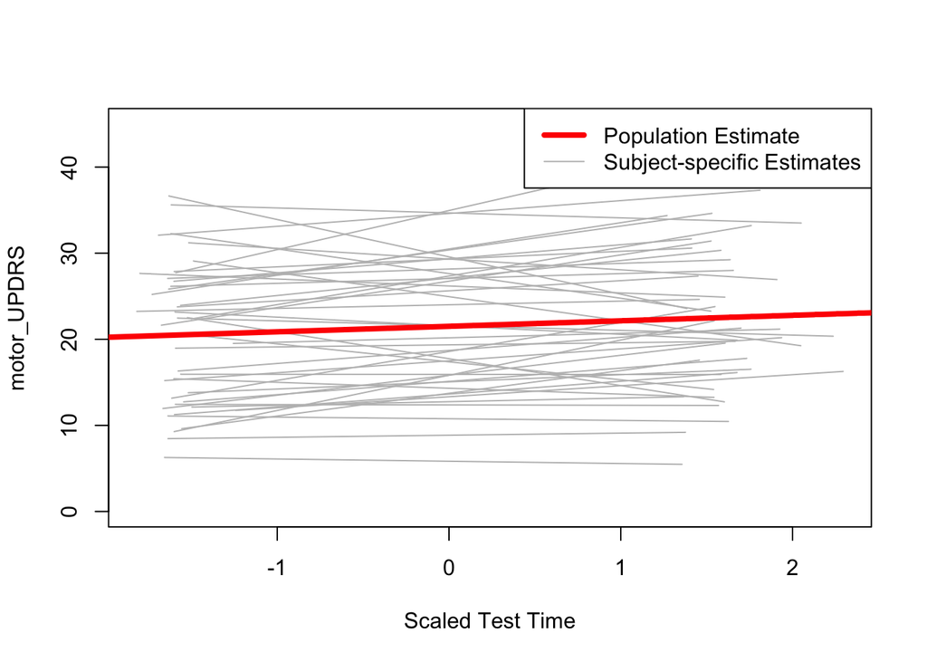

```r
# create an empty plot
plot(NULL,
     xlim=c(min(pdata$s_test_time), max(pdata$s_test_time)),
     ylim=c(0,45),
     xlab = "Scaled Test Time", ylab = "motor_UPDRS")

# add predicted subject-specific estimates
ids = as.numeric(unique(pdata$subject))
for(i in ids) {

  x = range(pdata$s_test_time[pdata$subject==i])
  beta = as.numeric(coef(model2.6)$subject[i, c('(Intercept)', 's_test_time')])
  y = beta[1] + beta[2]*x
  lines (y~x, type="l",col='grey', lwd=1)

}

# get population estimate
fixed_beta <- fixef(model2.6)
# add population estimate
abline(fixed_beta['(Intercept)'],
       fixed_beta['s_test_time'],
       col='red', lwd=4)

# add legends
legend("topright",
       legend = c("Population Estimate", "Subject-specific Estimates"),
       col = c("red", "gray"),
       lwd = c(4, 1))
```

Yes, the slopes differ substantially between patients.

**8.** Conduct a likelihood ratio test for the model with versus without random slope. Which model is preferred?

```r
model2.6_ml = lmer(motor_UPDRS~s_age+sex+Jitter_Percent+Shimmer+NHR+PPE+s_test_time+(s_test_time|subject),
                   data=pdata, REML=FALSE)
model2.8 = lmer(motor_UPDRS~s_age+sex+Jitter_Percent+Shimmer+NHR+PPE+s_test_time+(1|subject),
                data=pdata,REML=FALSE)
anova(model2.8, model2.6_ml)
```

```
## Data: pdata
## Models:
## model2.8: motor_UPDRS ~ s_age + sex + Jitter_Percent + Shimmer + NHR + PPE + s_test_time + (1 | subject)
## model2.6_ml: motor_UPDRS ~ s_age + sex + Jitter_Percent + Shimmer + NHR + PPE + s_test_time + (s_test_time | subject)
##             npar   AIC   BIC logLik deviance  Chisq Df Pr(>Chisq)
## model2.8      10 26523 26590 -13252    26503
## model2.6_ml   12 20225 20305 -10100    20201 6302.5  2  < 2.2e-16 ***
## ---
## Signif. codes:  0 '***' 0.001 '**' 0.01 '*' 0.05 '.' 0.1 ' ' 1
```

The likelihood ratio test yields a chi-squared statistic of 6302.5 with 2 degrees of freedom. The corresponding p-value is less than $2.2 \times 10^{-16}$, which is below the significance level of 0.05. Therefore, we reject the null hypothesis that the variance of the random slope is equal to zero and conclude that the random slope model is preferred.

**9.** Recall that the p-values for likelihood ratio tests of random effects tend to be too large, and similarly, the AIC can select overly simple models, which is a consequence of the null hypothesis being on the boundary of the parameter space (i.e., variance = 0). We will calculate a simulation-based p-value for the restricted likelihood ratio test (i.e., from REML). Unfortunately, the simulation approach assumes the random effects are uncorrelated. Refit the model with the random slope and intercept uncorrelated using REML. Then use the function `exactRLRT()` to test the null hypothesis that the variance of the random slope is equal to zero. Which model is preferred? The code below is from the help manual for `exactRLRT()`.

```r
library(RLRsim)
data(sleepstudy, package = "lme4")
mA <- lme4::lmer(Reaction ~ I(Days-4.5) + (1|Subject) + (0 + I(Days-4.5)|Subject),
data = sleepstudy)
m0 <- update(mA, . ~ . - (0 + I(Days-4.5)|Subject))
m.slope <- update(mA, . ~ . - (1|Subject))
#test for subject specific slopes:
exactRLRT(m.slope, mA, m0)
```

```
##
##  simulated finite sample distribution of RLRT.
##
##  (p-value based on 10000 simulated values)
##
## data:
## RLRT = 32.916, p-value < 2.2e-16
```

```r
mA <- lme4::lmer(motor_UPDRS~s_age+sex+Jitter_Percent+Shimmer+NHR+PPE+s_test_time+(1|subject)+(0+s_test_time|subject),
data = pdata)
m0 <- update(mA, . ~ . - (0+s_test_time|subject))
m.slope <- update(mA, . ~ . - (1|subject))
#test for subject specific slopes:
exactRLRT(m.slope, mA, m0)
```

```
##
##  simulated finite sample distribution of RLRT.
##
##  (p-value based on 10000 simulated values)
##
## data:
## RLRT = 6302.6, p-value < 2.2e-16
```

The p-value of the restricted likelihood ratio test is $<$ 2.2e-16, which is below the significance level of 0.05. Therefore, we reject the null hypothesis that the variance of the random slope is equal to zero and conclude that the random slope model is preferred.